# Unsupervised Learning: Trade&Ahead

**Marks: 60**

## Context

The stock market has consistently proven to be a good place to invest in and save for the future. There are a lot of compelling reasons to invest in stocks. It can help in fighting inflation, create wealth, and also provides some tax benefits. Good steady returns on investments over a long period of time can also grow a lot more than seems possible. Also, thanks to the power of compound interest, the earlier one starts investing, the larger the corpus one can have for retirement. Overall, investing in stocks can help meet life's financial aspirations.

It is important to maintain a diversified portfolio when investing in stocks in order to maximise earnings under any market condition. Having a diversified portfolio tends to yield higher returns and face lower risk by tempering potential losses when the market is down. It is often easy to get lost in a sea of financial metrics to analyze while determining the worth of a stock, and doing the same for a multitude of stocks to identify the right picks for an individual can be a tedious task. By doing a cluster analysis, one can identify stocks that exhibit similar characteristics and ones which exhibit minimum correlation. This will help investors better analyze stocks across different market segments and help protect against risks that could make the portfolio vulnerable to losses.

## Objective

Trade&Ahead is a financial consultancy firm who provide their customers with personalized investment strategies. They have hired you as a Data Scientist and provided you with data comprising stock price and some financial indicators for a few companies listed under the New York Stock Exchange. They have assigned you the tasks of analyzing the data, grouping the stocks based on the attributes provided, and sharing insights about the characteristics of each group.

### Data Dictionary

- Ticker Symbol: An abbreviation used to uniquely identify publicly traded shares of a particular stock on a particular stock market
- Company: Name of the company
- GICS Sector: The specific economic sector assigned to a company by the Global Industry Classification Standard (GICS) that best defines its business operations
- GICS Sub Industry: The specific sub-industry group assigned to a company by the Global Industry Classification Standard (GICS) that best defines its business operations
- Current Price: Current stock price in dollars
- Price Change: Percentage change in the stock price in 13 weeks
- Volatility: Standard deviation of the stock price over the past 13 weeks
- ROE: A measure of financial performance calculated by dividing net income by shareholders' equity (shareholders' equity is equal to a company's assets minus its debt)
- Cash Ratio: The ratio of a company's total reserves of cash and cash equivalents to its total current liabilities
- Net Cash Flow: The difference between a company's cash inflows and outflows (in dollars)
- Net Income: Revenues minus expenses, interest, and taxes (in dollars)
- Earnings Per Share: Company's net profit divided by the number of common shares it has outstanding (in dollars)
- Estimated Shares Outstanding: Company's stock currently held by all its shareholders
- P/E Ratio: Ratio of the company's current stock price to the earnings per share
- P/B Ratio: Ratio of the company's stock price per share by its book value per share (book value of a company is the net difference between that company's total assets and total liabilities)

## Importing necessary libraries and data

```python
%reload_ext nb_black

import numpy as np
import pandas as pd

import matplotlib.pyplot as plt
import seaborn as sns

sns.set_theme()

pd.set_option("display.max_columns", None)
pd.set_option("display.max_rows", 200)

from sklearn.preprocessing import StandardScaler

from scipy.spatial.distance import cdist, pdist

from sklearn.cluster import KMeans
from sklearn.metrics import silhouette_score
from scipy.cluster.hierarchy import dendrogram, linkage, cophenet
from sklearn.decomposition import PCA
from sklearn.cluster import AgglomerativeClustering
from yellowbrick.cluster import KElbowVisualizer, SilhouetteVisualizer

import warnings

warnings.filterwarnings("ignore")
```

## Data Overview

- Observations
- Sanity checks

```python
data = pd.read_csv("stock_data.csv")
```

```python
pd.options.display.float_format = "{:.5f}".format
```

```python
data.shape
```

```
(340, 15)
```

The data has 340 rows and 15 colons

```python
data.sample(n=10, random_state=1)
```

|  | Ticker Symbol | Security | GICS Sector | GICS Sub Industry | Current Price | Price Change | Volatility | ROE | Cash Ratio | Net Cash Flow | Net Income | Earnings Per Share | Estimated Shares Outstanding | P/E Ratio | P/B Ratio |
| --- | --- | --- | --- | --- | --- | --- | --- | --- | --- | --- | --- | --- | --- | --- | --- |
| 102 | DVN | Devon Energy Corp. | Energy | Oil & Gas Exploration & Production | 32.00000 | -15.47808 | 2.92370 | 205 | 70 | 830000000 | -14454000000 | -35.55000 | 406582278.50000 | 93.08929 | 1.78562 |
| 125 | FB | Facebook | Information Technology | Internet Software & Services | 104.66000 | 16.22432 | 1.32061 | 8 | 958 | 592000000 | 3669000000 | 1.31000 | 2800763359.00000 | 79.89313 | 5.88447 |
| 11 | AIV | Apartment Investment & Mgmt | Real Estate | REITs | 40.03000 | 7.57861 | 1.16333 | 15 | 47 | 21818000 | 248710000 | 1.52000 | 163625000.00000 | 26.33553 | -1.26933 |
| 248 | PG | Procter & Gamble | Consumer Staples | Personal Products | 79.41000 | 10.66054 | 0.80606 | 17 | 129 | 160383000 | 636056000 | 3.28000 | 491391569.00000 | 24.07012 | -2.25675 |
| 238 | OXY | Occidental Petroleum | Energy | Oil & Gas Exploration & Production | 67.61000 | 0.86529 | 1.58952 | 32 | 64 | -588000000 | -7829000000 | -10.23000 | 765298142.70000 | 93.08929 | 3.34510 |
| 336 | YUM | Yum! Brands Inc | Consumer Discretionary | Restaurants | 52.51618 | -8.69892 | 1.47888 | 142 | 27 | 159000000 | 1293000000 | 2.97000 | 435353535.40000 | 17.68221 | -3.83826 |
| 112 | EQT | EQT Corporation | Energy | Oil & Gas Exploration & Production | 52.13000 | -21.25377 | 2.36488 | 2 | 201 | 523803000 | 85171000 | 0.56000 | 152091071.40000 | 93.08929 | 9.56795 |
| 147 | HAL | Halliburton Co. | Energy | Oil & Gas Equipment & Services | 34.04000 | -5.10175 | 1.96606 | 4 | 189 | 7786000000 | -671000000 | -0.79000 | 849367088.60000 | 93.08929 | 17.34586 |
| 89 | DFS | Discover Financial Services | Financials | Consumer Finance | 53.62000 | 3.65358 | 1.15990 | 20 | 99 | 2288000000 | 2297000000 | 5.14000 | 446887159.50000 | 10.43191 | -0.37593 |
| 173 | IVZ | Invesco Ltd. | Financials | Asset Management & Custody Banks | 33.48000 | 7.06748 | 1.58084 | 12 | 67 | 412000000 | 968100000 | 2.26000 | 428362831.90000 | 14.81416 | 4.21862 |

```python
df = data.copy()
```

```python
df.columns = [c.replace(" ", "_") for c in df.columns]
```

```python
df.info()
```

```
<class 'pandas.core.frame.DataFrame'>
RangeIndex: 340 entries, 0 to 339
Data columns (total 15 columns):
 #   Column                        Non-Null Count  Dtype
---  ------                        --------------  -----
 0   Ticker_Symbol                 340 non-null    object
 1   Security                      340 non-null    object
 2   GICS_Sector                   340 non-null    object
 3   GICS_Sub_Industry             340 non-null    object
 4   Current_Price                 340 non-null    float64
 5   Price_Change                  340 non-null    float64
 6   Volatility                    340 non-null    float64
 7   ROE                           340 non-null    int64
 8   Cash_Ratio                    340 non-null    int64
 9   Net_Cash_Flow                 340 non-null    int64
 10  Net_Income                    340 non-null    int64
 11  Earnings_Per_Share            340 non-null    float64
 12  Estimated_Shares_Outstanding  340 non-null    float64
 13  P/E_Ratio                     340 non-null    float64
 14  P/B_Ratio                     340 non-null    float64
dtypes: float64(7), int64(4), object(4)
memory usage: 40.0+ KB
```

The GICS sector, sub_industry, company_name,Ticker_symbol are object type, while other columns are numerical.

```python
df.describe().T
```

|  | count | mean | std | min | 25% | 50% | 75% | max |
| --- | --- | --- | --- | --- | --- | --- | --- | --- |
| Current_Price | 340.00000 | 80.86234 | 98.05509 | 4.50000 | 38.55500 | 59.70500 | 92.88000 | 1274.94995 |
| Price_Change | 340.00000 | 4.07819 | 12.00634 | -47.12969 | -0.93948 | 4.81950 | 10.69549 | 55.05168 |
| Volatility | 340.00000 | 1.52598 | 0.59180 | 0.73316 | 1.13488 | 1.38559 | 1.69555 | 4.58004 |
| ROE | 340.00000 | 39.59706 | 96.54754 | 1.00000 | 9.75000 | 15.00000 | 27.00000 | 917.00000 |
| Cash_Ratio | 340.00000 | 70.02353 | 90.42133 | 0.00000 | 18.00000 | 47.00000 | 99.00000 | 958.00000 |
| Net_Cash_Flow | 340.00000 | 55537620.58824 | 1946365312.17579 | -11208000000.00000 | -193906500.00000 | 2098000.00000 | 169810750.00000 | 20764000000.00000 |
| Net_Income | 340.00000 | 1494384602.94118 | 3940150279.32794 | -23528000000.00000 | 352301250.00000 | 707336000.00000 | 1899000000.00000 | 24442000000.00000 |
| Earnings_Per_Share | 340.00000 | 2.77666 | 6.58778 | -61.20000 | 1.55750 | 2.89500 | 4.62000 | 50.09000 |
| Estimated_Shares_Outstanding | 340.00000 | 577028337.75403 | 845849595.41769 | 27672156.86000 | 158848216.10000 | 309675137.80000 | 573117457.32500 | 6159292035.00000 |
| P/E_Ratio | 340.00000 | 32.61256 | 44.34873 | 2.93545 | 15.04465 | 20.81988 | 31.76476 | 528.03907 |
| P/B_Ratio | 340.00000 | -1.71825 | 13.96691 | -76.11908 | -4.35206 | -1.06717 | 3.91707 | 129.06459 |

```python
df.isnull().sum()
```

```
Ticker_Symbol                   0
Security                        0
GICS_Sector                     0
GICS_Sub_Industry               0
Current_Price                   0
Price_Change                    0
Volatility                      0
ROE                             0
Cash_Ratio                      0
Net_Cash_Flow                   0
Net_Income                      0
Earnings_Per_Share              0
Estimated_Shares_Outstanding    0
P/E_Ratio                       0
P/B_Ratio                       0
dtype: int64
```

There are no null values

```python
df.duplicated().sum()
```

```
0
```

There are no duplicate values

## Exploratory Data Analysis (EDA)

- EDA is an important part of any project involving data.
- It is important to investigate and understand the data better before building a model with it.
- A few questions have been mentioned below which will help you approach the analysis in the right manner and generate insights from the data.
- A thorough analysis of the data, in addition to the questions mentioned below, should be done.

**Questions**:

1. What does the distribution of stock prices look like?
2. The stocks of which economic sector have seen the maximum price increase on average?
3. How are the different variables correlated with each other?
4. Cash ratio provides a measure of a company's ability to cover its short-term obligations using only cash and cash equivalents. How does the average cash ratio vary across economic sectors?
5. P/E ratios can help determine the relative value of a company's shares as they signify the amount of money an investor is willing to invest in a single share of a company per dollar of its earnings. How does the P/E ratio vary, on average, across economic sectors?

```python
def histogram_boxplot(data, feature, figsize=(12, 7), kde=False, bins=None):

    f2, (ax_box2, ax_hist2) = plt.subplots(
        nrows=2,  # Number of rows of the subplot grid= 2
        sharex=True,  # x-axis will be shared among all subplots
        gridspec_kw={"height_ratios": (0.25, 0.75)},
        figsize=figsize,
    )
    sns.boxplot(data=data, x=feature, ax=ax_box2, showmeans=True, color="violet")
    sns.histplot(
        data=data, x=feature, kde=kde, ax=ax_hist2, bins=bins, palette="winter"
    ) if bins else sns.histplot(data=data, x=feature, kde=kde, ax=ax_hist2)
    ax_hist2.axvline(data[feature].mean(), color="green", linestyle="--")
    ax_hist2.axvline(data[feature].median(), color="black", linestyle="-")
```

```python
def labeled_barplot(data, feature, perc=False, n=None):

    total = len(data[feature])  # length of the column
    count = data[feature].nunique()
    if n is None:
        plt.figure(figsize=(count + 1, 5))
    else:
        plt.figure(figsize=(n + 1, 5))

    plt.xticks(rotation=90, fontsize=15)
    ax = sns.countplot(
        data=data,
        x=feature,
        palette="Paired",
        order=data[feature].value_counts().index[:n].sort_values(),
    )

    for p in ax.patches:
        if perc == True:
            label = "{:.1f}%".format(100 * p.get_height() / total)
        else:
            label = p.get_height()

        x = p.get_x() + p.get_width() / 2
        y = p.get_height()

        ax.annotate(
            label,
            (x, y),
            ha="center",
            va="center",
            size=12,
            xytext=(0, 5),
            textcoords="offset points",
        )

    plt.show()
```

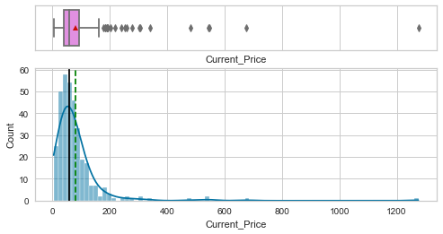

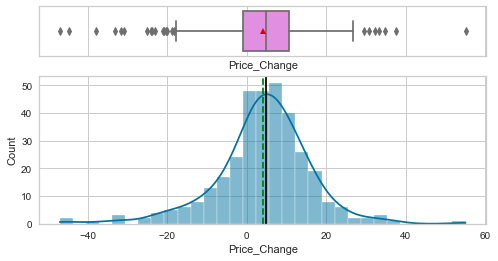

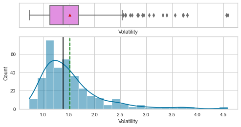

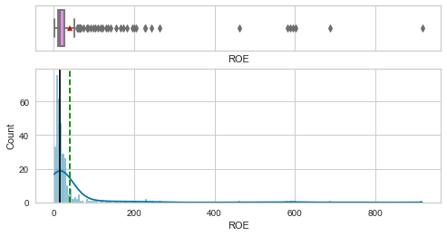

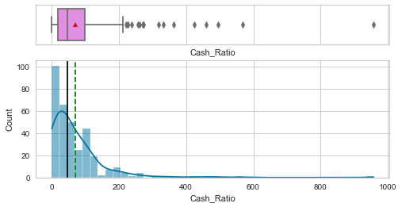

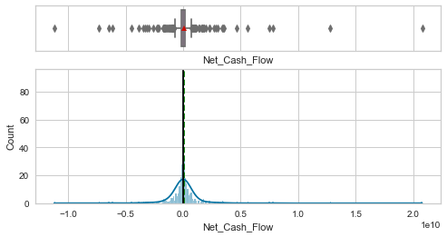

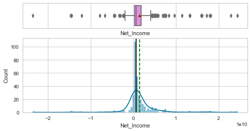

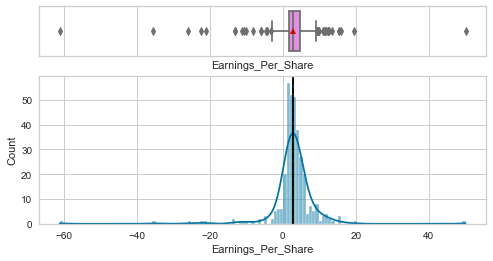

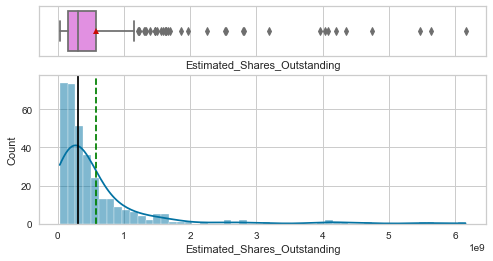

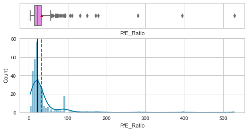

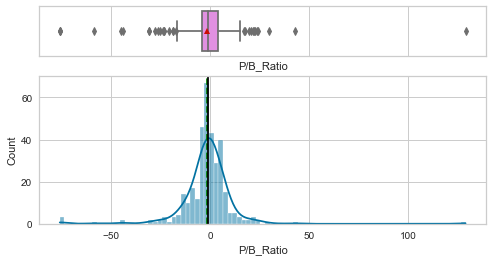

```python
num_col = df.select_dtypes(include=np.number).columns.tolist()

for item in num_col:
    histogram_boxplot(df, item, kde=True, figsize=(8, 4))
```

The stock price distribution is right skewed, while the price increase is evenly distributed

The velosity, ROE and cash ratios are also right skewed.

Outliers exist in all the parameters

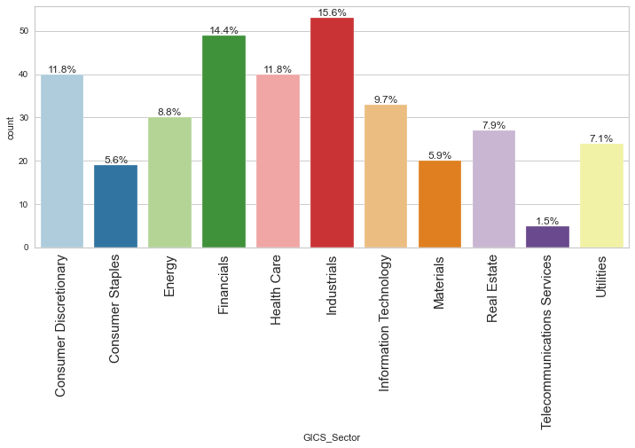

```python
labeled_barplot(df, "GICS_Sector", perc=True)
```

Industrials, Financials, consumer discretionary and health care have the most stock respectively, the four sectors contribute over 50% of the total stock.

[figure not shown]

```python
labeled_barplot(df, "GICS_Sub_Industry", perc=True)
```

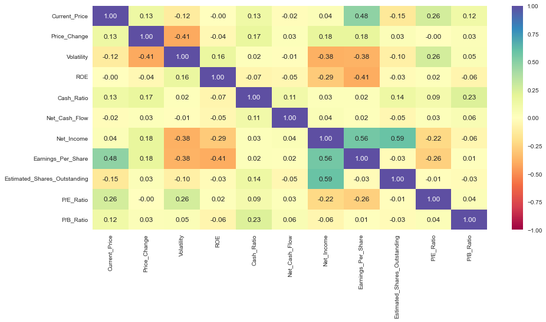

```python
plt.figure(figsize=(15, 7))
sns.heatmap(df.corr(), annot=True, vmin=-1, vmax=1, fmt=".2f", cmap="Spectral")
plt.show()
```

There is a positive correlation between net income and estimated share outstanding

There is a positive correlation between not income and earnings per share.

There is also a positive correlation between earnings per share and current prices.

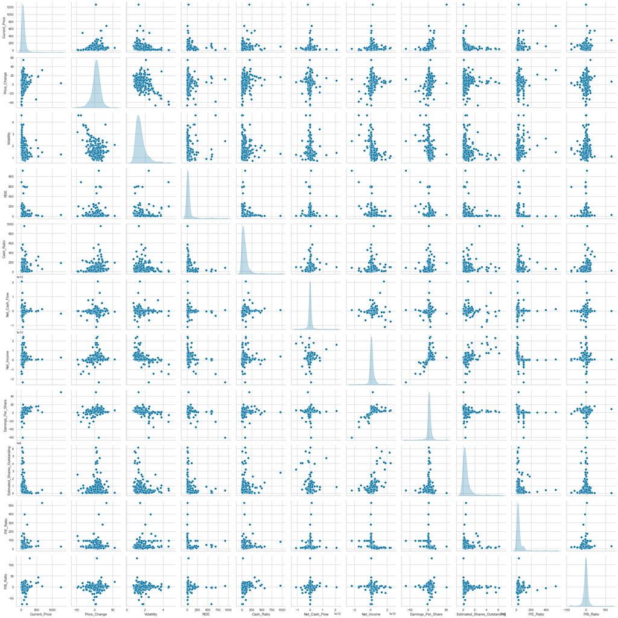

```python
sns.pairplot(data=df[num_col], diag_kind="kde")
plt.show()
```

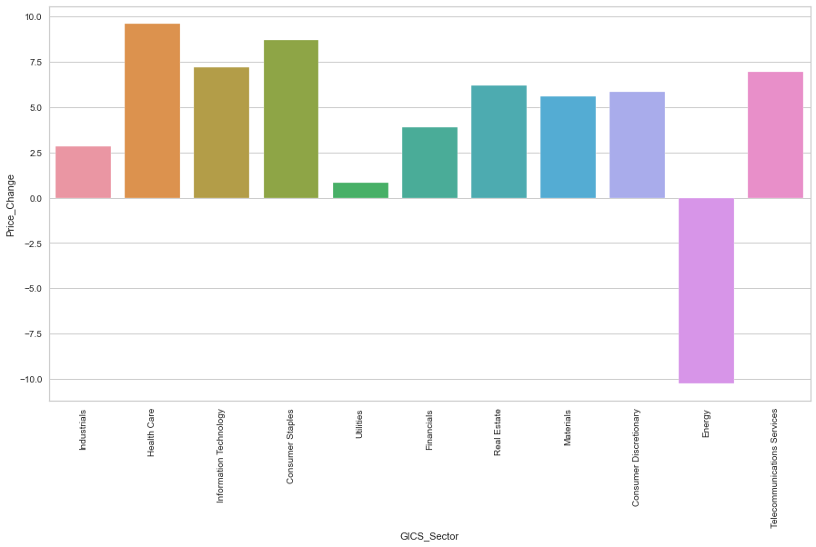

```python
plt.figure(figsize=(15, 8))
sns.barplot(data=df, x="GICS_Sector", y="Price_Change", ci=False)
plt.xticks(rotation=90)
plt.show()
```

Health care has the highiest price change followed by consumer staples

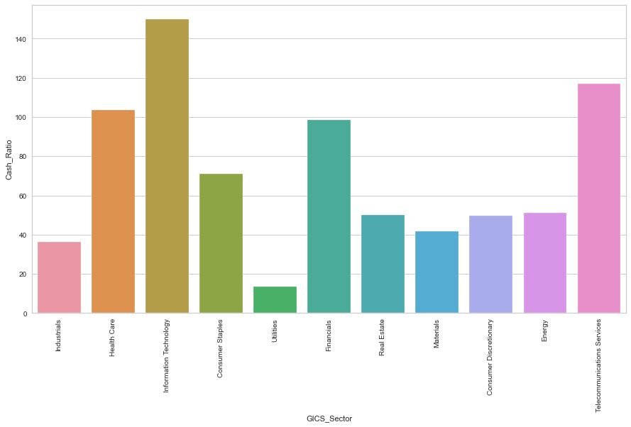

```python
plt.figure(figsize=(15, 8))
sns.barplot(data=df, x="GICS_Sector", y="Cash_Ratio", ci=False)
plt.xticks(rotation=90)
plt.show()
```

The IT sector has the highiest cash ratio, next is telecommunications services and health care

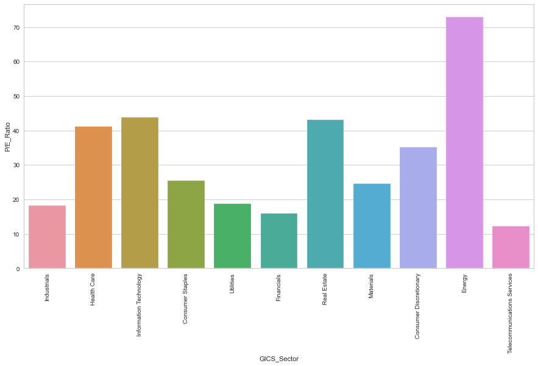

```python
plt.figure(figsize=(15, 8))
sns.barplot(data=df, x="GICS_Sector", y="P/E_Ratio", ci=False)
plt.xticks(rotation=90)
plt.show()
```

The energy sector has the highiest P/E ratio

## Data Preprocessing

- Duplicate value check
- Missing value treatment
- Outlier check
- Feature engineering (if needed)
- Any other preprocessing steps (if needed)

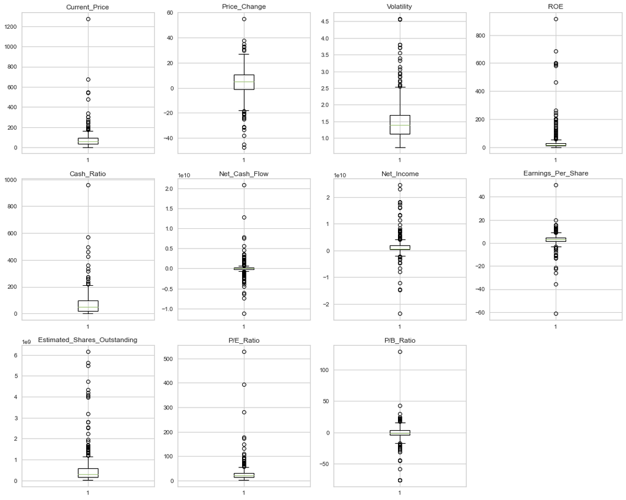

```python
plt.figure(figsize=(15, 12))

numeric_columns = df.select_dtypes(include=np.number).columns.tolist()

for i, variable in enumerate(numeric_columns):
    plt.subplot(3, 4, i + 1)
    plt.boxplot(df[variable], whis=1.5)
    plt.tight_layout()
    plt.title(variable)

plt.show()
```

## EDA

- It is a good idea to explore the data once again after manipulating it.

The data was not further manupulated, so there is no need for more EDA

```python
scaler = StandardScaler()
subset = df[num_col].copy()
subset_scaled = scaler.fit_transform(subset)
```

```python
subset_scaled_df = pd.DataFrame(subset_scaled, columns=subset.columns)
```

## K-means Clustering

```
Number of Clusters: 1 	Average Distortion: 2.5425069919221697
Number of Clusters: 2 	Average Distortion: 2.382318498894466
Number of Clusters: 3 	Average Distortion: 2.2659465936501304
Number of Clusters: 4 	Average Distortion: 2.182301540694897
Number of Clusters: 5 	Average Distortion: 2.1176989906805734
Number of Clusters: 6 	Average Distortion: 2.0568349346658827
Number of Clusters: 7 	Average Distortion: 2.033104896666226
Number of Clusters: 8 	Average Distortion: 1.9672692838803147
Number of Clusters: 9 	Average Distortion: 1.9036896638695089
Number of Clusters: 10 	Average Distortion: 1.861590476422522
Number of Clusters: 11 	Average Distortion: 1.7984469378786592
Number of Clusters: 12 	Average Distortion: 1.7605776598509937
```

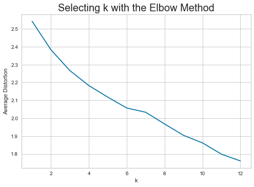

```python
clusters = range(1, 13)
meanDistortions = []

for k in clusters:
    model = KMeans(n_clusters=k)
    model.fit(subset_scaled_df)
    prediction = model.predict(subset_scaled_df)
    distortion = (
        sum(
            np.min(cdist(subset_scaled_df, model.cluster_centers_, "euclidean"), axis=1)
        )
        / subset_scaled_df.shape[0]
    )

    meanDistortions.append(distortion)

    print("Number of Clusters:", k, "\tAverage Distortion:", distortion)

plt.plot(clusters, meanDistortions, "bx-")
plt.xlabel("k")
plt.ylabel("Average Distortion")
plt.title("Selecting k with the Elbow Method", fontsize=20)
```

Possible K values are 4, 7 or 11. Let's check the silhouette score

```
For n_clusters = 2, silhouette score is 0.43969639509980457
For n_clusters = 3, silhouette score is 0.465292959074158
For n_clusters = 4, silhouette score is 0.5293082651304898
For n_clusters = 5, silhouette score is 0.40999356683171667
For n_clusters = 6, silhouette score is 0.393118557264422
For n_clusters = 7, silhouette score is 0.3975530436451212
For n_clusters = 8, silhouette score is 0.4012847345639638
For n_clusters = 9, silhouette score is 0.3851259484250313
For n_clusters = 10, silhouette score is 0.14067707026493098
For n_clusters = 11, silhouette score is 0.15573945831183594
For n_clusters = 12, silhouette score is 0.1582607906367337
```

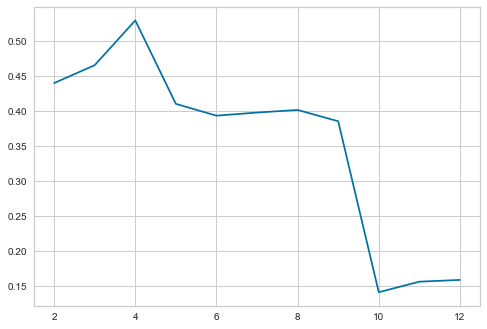

```python
sil_score = []
cluster_list = list(range(2, 13))
for n_clusters in cluster_list:
    clusterer = KMeans(n_clusters=n_clusters)
    preds = clusterer.fit_predict((subset_scaled_df))
    score = silhouette_score(subset_scaled_df, preds)
    sil_score.append(score)
    print("For n_clusters = {}, silhouette score is {}".format(n_clusters, score))

plt.plot(cluster_list, sil_score)
```

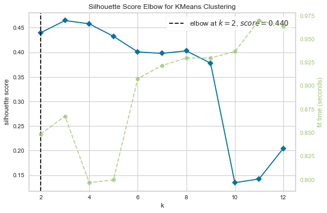

```python
model = KMeans(random_state=1)
visualizer = KElbowVisualizer(model, k=(2, 13), metric="silhouette", timings=True)
visualizer.fit(subset_scaled_df)
visualizer.show()
```

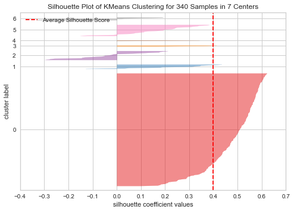

```python
visualizer = SilhouetteVisualizer(KMeans(7, random_state=1))
visualizer.fit(subset_scaled_df)
visualizer.show()
```

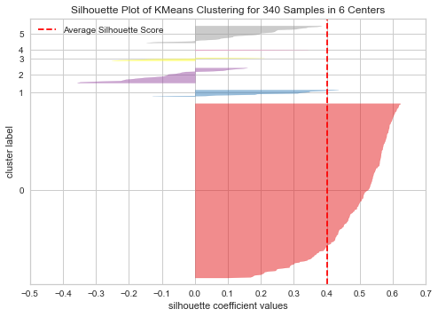

```python
visualizer = SilhouetteVisualizer(KMeans(6, random_state=1))
visualizer.fit(subset_scaled_df)
visualizer.show()
```

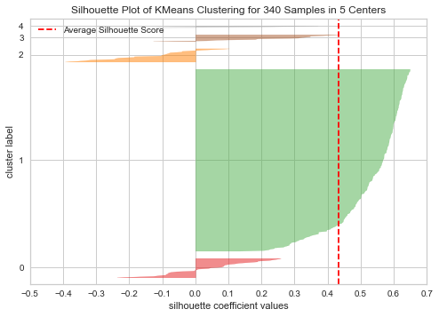

```python
visualizer = SilhouetteVisualizer(KMeans(5, random_state=1))
visualizer.fit(subset_scaled_df)
visualizer.show()
```

Let's take 7 as the most appropriate value for K

```python
kmeans = KMeans(n_clusters=7, random_state=0)
kmeans.fit(subset_scaled_df)
```

```
KMeans(n_clusters=7, random_state=0)
```

CLUSTER PROFILING

```python
df2 = df.copy()
```

```python
subset_scaled_df["KM_segments"] = kmeans.labels_
df2["KM_segments"] = kmeans.labels_
```

```python
Cluster_profile = df2.groupby("KM_segments").mean()
```

```python
Cluster_profile["count_in_each_segment"] = (
    df2.groupby("KM_segments")["Security"].count().values
)
```

```python
Cluster_profile.style.highlight_max(color="lightgreen", axis=0)
```

| KM_segments | Current_Price | Price_Change | Volatility | ROE | Cash_Ratio | Net_Cash_Flow | Net_Income | Earnings_Per_Share | Estimated_Shares_Outstanding | P/E_Ratio | P/B_Ratio | count_in_each_segment |
| --- | --- | --- | --- | --- | --- | --- | --- | --- | --- | --- | --- | --- |
| 0 | 48.103077 | 6.053507 | 1.163964 | 27.538462 | 77.230769 | 773230769.230769 | 14114923076.923077 | 3.958462 | 3918734987.169230 | 16.098039 | -4.253404 | 13 |
| 1 | 73.281231 | 5.002456 | 1.373721 | 25.303030 | 51.018939 | 5792560.606061 | 1517540458.333333 | 3.773201 | 422805643.026553 | 23.232765 | -3.313539 | 264 |
| 2 | 26.990000 | -14.060688 | 3.296307 | 603.000000 | 57.333333 | -585000000.000000 | -17555666666.666668 | -39.726667 | 481910081.666667 | 71.528835 | 1.638633 | 3 |
| 3 | 108.304002 | 10.737770 | 1.165694 | 566.200000 | 26.600000 | -278760000.000000 | 687180000.000000 | 1.548000 | 349607057.720000 | 34.898915 | -16.851358 | 5 |
| 4 | 632.714991 | 7.374164 | 1.541343 | 19.333333 | 158.333333 | -24046333.333333 | 907393166.666667 | 16.270000 | 125797901.323333 | 123.049240 | 35.355736 | 6 |
| 5 | 95.281515 | 14.717580 | 1.814754 | 25.954545 | 308.909091 | 645568272.727273 | 871490181.818182 | 2.006364 | 730848546.662727 | 57.950455 | 7.992920 | 22 |
| 6 | 37.282919 | -14.529500 | 2.820301 | 40.666667 | 47.555556 | -133624777.777778 | -1904442925.925926 | -4.957037 | 503635899.112593 | 86.787432 | 1.378738 | 27 |

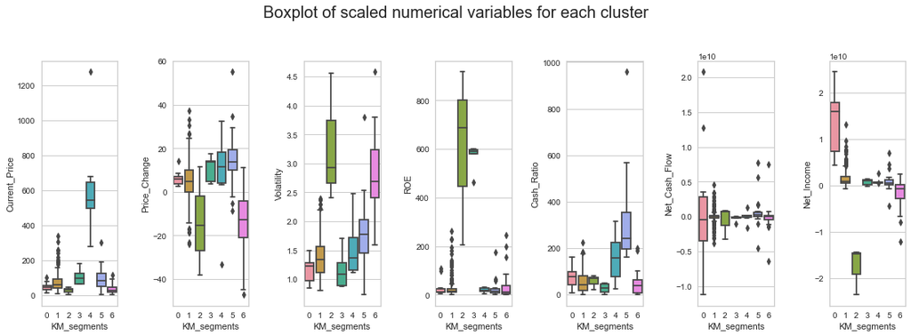

```python
fig, axes = plt.subplots(1, 7, figsize=(16, 6))
fig.suptitle("Boxplot of scaled numerical variables for each cluster", fontsize=20)
counter = 0
for ii in range(7):
    sns.boxplot(ax=axes[ii], y=df2[num_col[counter]], x=df2["KM_segments"])
    counter = counter + 1

fig.tight_layout(pad=2.0)
```

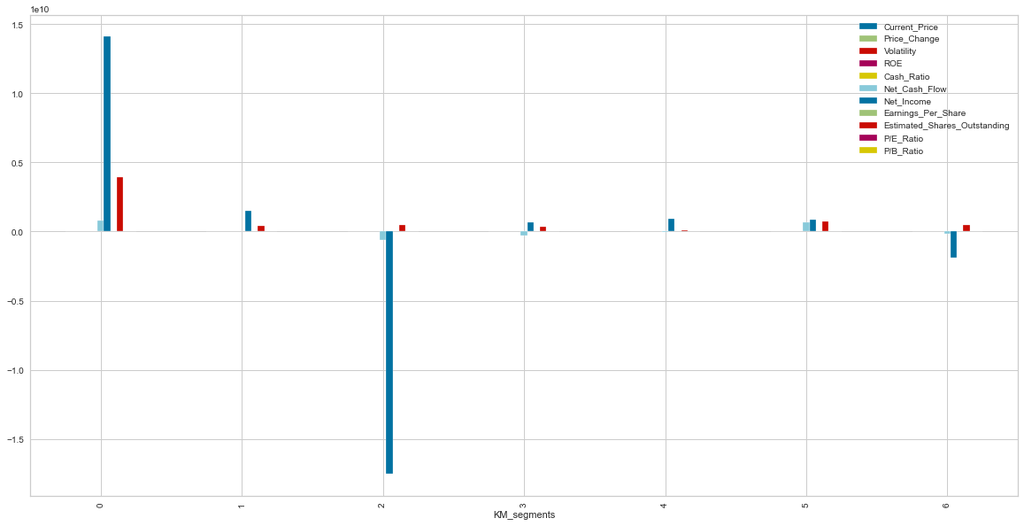

```python
df2.groupby("KM_segments").mean().plot.bar(figsize=(20, 10))
```

```python
df2.groupby(["KM_segments", "GICS_Sector"])["Security"].count()
```

```
KM_segments  GICS_Sector
0            Consumer Discretionary          1
             Consumer Staples                1
             Energy                          1
             Financials                      4
             Health Care                     3
             Information Technology          1
             Telecommunications Services     2
1            Consumer Discretionary         32
             Consumer Staples               15
             Energy                          5
             Financials                     44
             Health Care                    29
             Industrials                    50
             Information Technology         20
             Materials                      17
             Real Estate                    26
             Telecommunications Services     2
             Utilities                      24
2            Energy                          3
3            Consumer Discretionary          1
             Consumer Staples                2
             Financials                      1
             Industrials                     1
4            Consumer Discretionary          3
             Health Care                     2
             Information Technology          1
5            Consumer Discretionary          3
             Consumer Staples                1
             Energy                          1
             Health Care                     6
             Information Technology          8
             Materials                       1
             Real Estate                     1
             Telecommunications Services     1
6            Energy                         20
             Industrials                     2
             Information Technology          3
             Materials                       2
Name: Security, dtype: int64
```

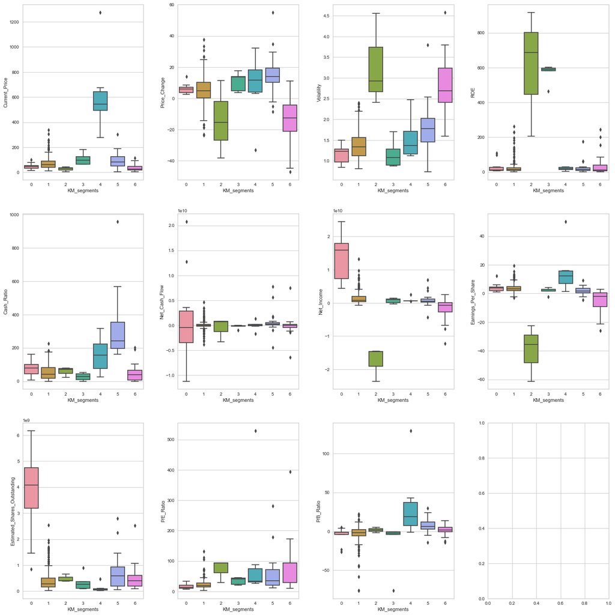

```python
fig, axes = plt.subplots(3, 4, figsize=(20, 20))
counter = 0

for ii in range(3):
    for jj in range(4):
        if counter < 11:
            sns.boxplot(
                ax=axes[ii][jj], data=df2, y=df2.columns[4 + counter], x="KM_segments",
            )
            counter = counter + 1

fig.tight_layout(pad=3.0)
```

```python
for cl in df2["KM_segments"].unique():
    print("In cluster {}, the following companies are present:".format(cl))
    print(df2[df2["KM_segments"] == cl]["Security"].unique())
    print()
```

```
In cluster 1, the following companies are present:
['American Airlines Group' 'AbbVie' 'Abbott Laboratories'
 'Archer-Daniels-Midland Co' 'Ameren Corp' 'American Electric Power'
 'AFLAC Inc' 'American International Group, Inc.'
 'Apartment Investment & Mgmt' 'Assurant Inc' 'Arthur J. Gallagher & Co.'
 'Akamai Technologies Inc' 'Albemarle Corp' 'Alaska Air Group Inc'
 'Allstate Corp' 'Applied Materials Inc' 'AMETEK Inc'
 'Affiliated Managers Group Inc' 'Ameriprise Financial'
 'American Tower Corp A' 'AutoNation Inc' 'Anthem Inc.' 'Aon plc'
 'Amphenol Corp' 'Activision Blizzard' 'AvalonBay Communities, Inc.'
 'American Water Works Company Inc' 'American Express Co' 'Boeing Company'
 'Baxter International Inc.' 'BB&T Corporation' 'Bard (C.R.) Inc.'
 'BIOGEN IDEC Inc.' 'The Bank of New York Mellon Corp.' 'Ball Corp'
 'Bristol-Myers Squibb' 'Boston Scientific' 'BorgWarner'
 'Boston Properties' 'Caterpillar Inc.' 'Chubb Limited' 'CBRE Group'
 'Crown Castle International Corp.' 'Carnival Corp.'
 'CF Industries Holdings Inc' 'Citizens Financial Group' 'Church & Dwight'
 'C. H. Robinson Worldwide' 'CIGNA Corp.' 'Cincinnati Financial'
 'Comerica Inc.' 'CME Group Inc.' 'Cummins Inc.' 'CMS Energy'
 'Centene Corporation' 'CenterPoint Energy' 'Capital One Financial'
 'The Cooper Companies' 'CSX Corp.' 'CenturyLink Inc'
 'Cognizant Technology Solutions' 'Citrix Systems' 'CVS Health'
 'Chevron Corp.' 'Dominion Resources' 'Delta Air Lines' 'Du Pont (E.I.)'
 'Deere & Co.' 'Discover Financial Services' 'Quest Diagnostics'
 'Danaher Corp.' 'The Walt Disney Company' 'Discovery Communications-A'
 'Discovery Communications-C' 'Delphi Automotive' 'Digital Realty Trust'
 'Dun & Bradstreet' 'Dover Corp.' 'Dr Pepper Snapple Group' 'Duke Energy'
 'DaVita Inc.' 'Ecolab Inc.' 'Consolidated Edison' 'Equifax Inc.'
 "Edison Int'l" 'Eastman Chemical' 'Equity Residential'
 'Eversource Energy' 'Essex Property Trust, Inc.' 'E*Trade'
 'Eaton Corporation' 'Entergy Corp.' 'Exelon Corp.' "Expeditors Int'l"
 'Expedia Inc.' 'Extra Space Storage' 'Fastenal Co'
 'Fortune Brands Home & Security' 'FirstEnergy Corp'
 'Fidelity National Information Services' 'Fiserv Inc' 'FLIR Systems'
 'Fluor Corp.' 'Flowserve Corporation' 'FMC Corporation'
 'Federal Realty Investment Trust' 'General Dynamics'
 'General Growth Properties Inc.' 'Corning Inc.' 'General Motors'
 'Genuine Parts' 'Garmin Ltd.' 'Goodyear Tire & Rubber'
 'Grainger (W.W.) Inc.' 'Hasbro Inc.' 'Huntington Bancshares'
 'HCA Holdings' 'Welltower Inc.' 'HCP Inc.' 'Hartford Financial Svc.Gp.'
```

[output cut: 67 more lines]

```
['Anadarko Petroleum Corp' 'Arconic Inc' 'Baker Hughes Inc'
 'Cabot Oil & Gas' 'Concho Resources' 'EOG Resources' 'EQT Corporation'
 'Freeport-McMoran Cp & Gld' 'Hess Corporation'
 'Hewlett Packard Enterprise' 'Kinder Morgan' 'The Mosaic Company'
 'Marathon Oil Corp.' 'Murphy Oil' 'Noble Energy Inc' 'Netflix Inc.'
 'Newfield Exploration Co' 'National Oilwell Varco Inc.' 'ONEOK'
 'Occidental Petroleum' 'Quanta Services Inc.' 'Range Resources Corp.'
 'Spectra Energy Corp.' 'Southwestern Energy' 'Teradata Corp.'
 'Williams Cos.' 'Cimarex Energy']

In cluster 0, the following companies are present:
['Bank of America Corp' 'Citigroup Inc.' 'Ford Motor' 'Gilead Sciences'
 'Intel Corp.' 'JPMorgan Chase & Co.' 'Coca Cola Company' 'Merck & Co.'
 'Pfizer Inc.' 'AT&T Inc' 'Verizon Communications' 'Wells Fargo'
 'Exxon Mobil Corp.']
```

## Hierarchical Clustering

```python
df3 = subset_scaled_df.copy()
```

```python
distance_metrics = ["euclidean", "chebyshev", "mahalanobis", "cityblock"]

linkage_methods = ["single", "complete", "average", "weighted"]

high_cophenet_corr = 0
high_dm_lm = [0, 0]

for dm in distance_metrics:
    for lm in linkage_methods:
        Z = linkage(df3, metric=dm, method=lm)
        c, coph_dists = cophenet(Z, pdist(df3))
        print(
            "Cophenetic correlation for {} distance and {} linkage is {}.".format(
                dm.capitalize(), lm, c
            )
        )
        if high_cophenet_corr < c:
            high_cophenet_corr = c
            high_dm_lm[0] = dm
            high_dm_lm[1] = lm
```

```
Cophenetic correlation for Euclidean distance and single linkage is 0.9292860586044501.
Cophenetic correlation for Euclidean distance and complete linkage is 0.8989333235142748.
Cophenetic correlation for Euclidean distance and average linkage is 0.9443356936102916.
Cophenetic correlation for Euclidean distance and weighted linkage is 0.9195624993128418.
Cophenetic correlation for Chebyshev distance and single linkage is 0.9226444172132522.
Cophenetic correlation for Chebyshev distance and complete linkage is 0.8585624866711365.
Cophenetic correlation for Chebyshev distance and average linkage is 0.9449462311447745.
Cophenetic correlation for Chebyshev distance and weighted linkage is 0.9341698457019657.
Cophenetic correlation for Mahalanobis distance and single linkage is 0.9226912748349274.
Cophenetic correlation for Mahalanobis distance and complete linkage is 0.8581033295236967.
Cophenetic correlation for Mahalanobis distance and average linkage is 0.9193815623892934.
Cophenetic correlation for Mahalanobis distance and weighted linkage is 0.9125719822401562.
Cophenetic correlation for Cityblock distance and single linkage is 0.9318251447600471.
Cophenetic correlation for Cityblock distance and complete linkage is 0.8783832998676842.
Cophenetic correlation for Cityblock distance and average linkage is 0.9325860636790531.
Cophenetic correlation for Cityblock distance and weighted linkage is 0.8459947780495689.
```

```python
print(
    "Highest cophenetic correlation is {}, which is obtained with {} distance and {} linkage.".format(
        high_cophenet_corr, high_dm_lm[0].capitalize(), high_dm_lm[1]
    )
)
```

```
Highest cophenetic correlation is 0.9449462311447745, which is obtained with Chebyshev distance and average linkage.
```

Let's explore different linkage methods with Chebyshev distance only

```python
linkage_methods = ["single", "complete", "average", "weighted"]

high_cophenet_corr = 0
high_dm_lm = [0, 0]

for lm in linkage_methods:
    Z = linkage(df3, metric="chebyshev", method=lm)
    c, coph_dists = cophenet(Z, pdist(df3))
    print("Cophenetic correlation for {} linkage is {}.".format(lm, c))
    if high_cophenet_corr < c:
        high_cophenet_corr = c
        high_dm_lm[0] = "chebyshev"
        high_dm_lm[1] = lm
```

```
Cophenetic correlation for single linkage is 0.9226444172132522.
Cophenetic correlation for complete linkage is 0.8585624866711365.
Cophenetic correlation for average linkage is 0.9449462311447745.
Cophenetic correlation for weighted linkage is 0.9341698457019657.
```

```python
print(
    "Highest cophenetic correlation is {}, which is obtained with {} linkage.".format(
        high_cophenet_corr, high_dm_lm[1]
    )
)
```

```
Highest cophenetic correlation is 0.9449462311447745, which is obtained with average linkage.
```

Let's see the dendrograms for the different linkage methods

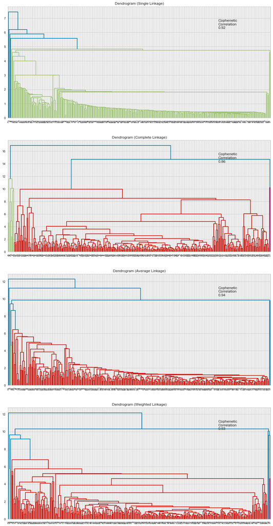

```python
linkage_methods = ["single", "complete", "average", "weighted"]

compare_cols = ["Linkage", "Cophenetic Coefficient"]
compare = []

fig, axs = plt.subplots(len(linkage_methods), 1, figsize=(15, 30))

for i, method in enumerate(linkage_methods):
    Z = linkage(df3, metric="chebyshev", method=method)

    dendrogram(Z, ax=axs[i])
    axs[i].set_title(f"Dendrogram ({method.capitalize()} Linkage)")

    coph_corr, coph_dist = cophenet(Z, pdist(df3))
    axs[i].annotate(
        f"Cophenetic\nCorrelation\n{coph_corr:0.2f}",
        (0.80, 0.80),
        xycoords="axes fraction",
    )
```

```python
df_cop = pd.DataFrame(compare, columns=compare_cols)
df_cop = df_cop.sort_values(by="Cophenetic Coefficient")
df_cop
```

[output not shown]

```python
HCmodel = AgglomerativeClustering(n_clusters=5, affinity="chebyshev", linkage="average")
HCmodel.fit(df3)
```

```
AgglomerativeClustering(affinity='chebyshev', linkage='average', n_clusters=5)
```

```python
df3["HC_Clusters"] = HCmodel.labels_
df2["HC_Clusters"] = HCmodel.labels_
```

Cluster Profiling

```python
cluster_profile = df2.groupby("HC_Clusters").mean()
```

```python
cluster_profile["count_in_each_segments"] = (
    df2.groupby("HC_Clusters")["Security"].count().values
)
```

```python
for cl in df2["HC_Clusters"].unique():
    print("In cluster {}, the following companies are present:".format(cl))
    print(df2[df2["HC_Clusters"] == cl]["Security"].unique())
    print()
```

```
In cluster 0, the following companies are present:
['American Airlines Group' 'AbbVie' 'Abbott Laboratories'
 'Adobe Systems Inc' 'Analog Devices, Inc.' 'Archer-Daniels-Midland Co'
 'Alliance Data Systems' 'Ameren Corp' 'American Electric Power'
 'AFLAC Inc' 'American International Group, Inc.'
 'Apartment Investment & Mgmt' 'Assurant Inc' 'Arthur J. Gallagher & Co.'
 'Akamai Technologies Inc' 'Albemarle Corp' 'Alaska Air Group Inc'
 'Allstate Corp' 'Allegion' 'Alexion Pharmaceuticals'
 'Applied Materials Inc' 'AMETEK Inc' 'Affiliated Managers Group Inc'
 'Amgen Inc' 'Ameriprise Financial' 'American Tower Corp A'
 'AutoNation Inc' 'Anthem Inc.' 'Aon plc' 'Anadarko Petroleum Corp'
 'Amphenol Corp' 'Arconic Inc' 'Activision Blizzard'
 'AvalonBay Communities, Inc.' 'Broadcom'
 'American Water Works Company Inc' 'American Express Co' 'Boeing Company'
 'Bank of America Corp' 'Baxter International Inc.' 'BB&T Corporation'
 'Bard (C.R.) Inc.' 'Baker Hughes Inc' 'BIOGEN IDEC Inc.'
 'The Bank of New York Mellon Corp.' 'Ball Corp' 'Bristol-Myers Squibb'
 'Boston Scientific' 'BorgWarner' 'Boston Properties' 'Citigroup Inc.'
 'Caterpillar Inc.' 'Chubb Limited' 'CBRE Group'
 'Crown Castle International Corp.' 'Carnival Corp.' 'Celgene Corp.'
 'CF Industries Holdings Inc' 'Citizens Financial Group' 'Church & Dwight'
 'Chesapeake Energy' 'C. H. Robinson Worldwide' 'Charter Communications'
 'CIGNA Corp.' 'Cincinnati Financial' 'Colgate-Palmolive' 'Comerica Inc.'
 'CME Group Inc.' 'Chipotle Mexican Grill' 'Cummins Inc.' 'CMS Energy'
 'Centene Corporation' 'CenterPoint Energy' 'Capital One Financial'
 'Cabot Oil & Gas' 'The Cooper Companies' 'CSX Corp.' 'CenturyLink Inc'
 'Cognizant Technology Solutions' 'Citrix Systems' 'CVS Health'
 'Chevron Corp.' 'Concho Resources' 'Dominion Resources' 'Delta Air Lines'
 'Du Pont (E.I.)' 'Deere & Co.' 'Discover Financial Services'
 'Quest Diagnostics' 'Danaher Corp.' 'The Walt Disney Company'
 'Discovery Communications-A' 'Discovery Communications-C'
 'Delphi Automotive' 'Digital Realty Trust' 'Dun & Bradstreet'
 'Dover Corp.' 'Dr Pepper Snapple Group' 'Duke Energy' 'DaVita Inc.'
 'Devon Energy Corp.' 'eBay Inc.' 'Ecolab Inc.' 'Consolidated Edison'
 'Equifax Inc.' "Edison Int'l" 'Eastman Chemical' 'EOG Resources'
 'Equinix' 'Equity Residential' 'EQT Corporation' 'Eversource Energy'
 'Essex Property Trust, Inc.' 'E*Trade' 'Eaton Corporation'
 'Entergy Corp.' 'Edwards Lifesciences' 'Exelon Corp.' "Expeditors Int'l"
 'Expedia Inc.' 'Extra Space Storage' 'Ford Motor' 'Fastenal Co'
 'Fortune Brands Home & Security' 'Freeport-McMoran Cp & Gld'
```

[output cut: 64 more lines]

```
 'Cimarex Energy' 'Xcel Energy Inc' 'XL Capital' 'Exxon Mobil Corp.'
 'Dentsply Sirona' 'Xerox Corp.' 'Xylem Inc.' 'Yahoo Inc.'
 'Yum! Brands Inc' 'Zimmer Biomet Holdings' 'Zions Bancorp' 'Zoetis']

In cluster 2, the following companies are present:
['Amazon.com Inc']

In cluster 4, the following companies are present:
['Apache Corporation']

In cluster 3, the following companies are present:
['Facebook']

In cluster 1, the following companies are present:
['Priceline.com Inc']
```

```python
cluster_profile.style.highlight_max(color="lightgreen", axis=0)
```

| HC_Clusters | Current_Price | Price_Change | Volatility | ROE | Cash_Ratio | Net_Cash_Flow | Net_Income | Earnings_Per_Share | Estimated_Shares_Outstanding | P/E_Ratio | P/B_Ratio | KM_segments | count_in_each_segments |
| --- | --- | --- | --- | --- | --- | --- | --- | --- | --- | --- | --- | --- | --- |
| 0 | 75.575081 | 3.939003 | 1.524932 | 37.217262 | 67.047619 | 53366598.214286 | 1561911919.642857 | 2.835074 | 572880555.109821 | 30.838681 | -1.779500 | 1.684524 | 336 |
| 1 | 1274.949951 | 3.190527 | 1.268340 | 29.000000 | 184.000000 | -1671386000.000000 | 2551360000.000000 | 50.090000 | 50935516.070000 | 25.453183 | -1.052429 | 4.000000 | 1 |
| 2 | 675.890015 | 32.268105 | 1.460386 | 4.000000 | 58.000000 | 1333000000.000000 | 596000000.000000 | 1.280000 | 465625000.000000 | 528.039074 | 3.904430 | 4.000000 | 1 |
| 3 | 104.660004 | 16.224320 | 1.320606 | 8.000000 | 958.000000 | 592000000.000000 | 3669000000.000000 | 1.310000 | 2800763359.000000 | 79.893133 | 5.884467 | 5.000000 | 1 |
| 4 | 44.470001 | 11.397804 | 2.405408 | 917.000000 | 80.000000 | 698000000.000000 | -23528000000.000000 | -61.200000 | 384444444.400000 | 93.089287 | 4.970809 | 2.000000 | 1 |

```python
df2.groupby(["HC_Clusters", "GICS_Sector"])["Security"].count()
```

```
HC_Clusters  GICS_Sector
0            Consumer Discretionary         38
             Consumer Staples               19
             Energy                         29
             Financials                     49
             Health Care                    40
             Industrials                    53
             Information Technology         32
             Materials                      20
             Real Estate                    27
             Telecommunications Services     5
             Utilities                      24
1            Consumer Discretionary          1
2            Consumer Discretionary          1
3            Information Technology          1
4            Energy                          1
Name: Security, dtype: int64
```

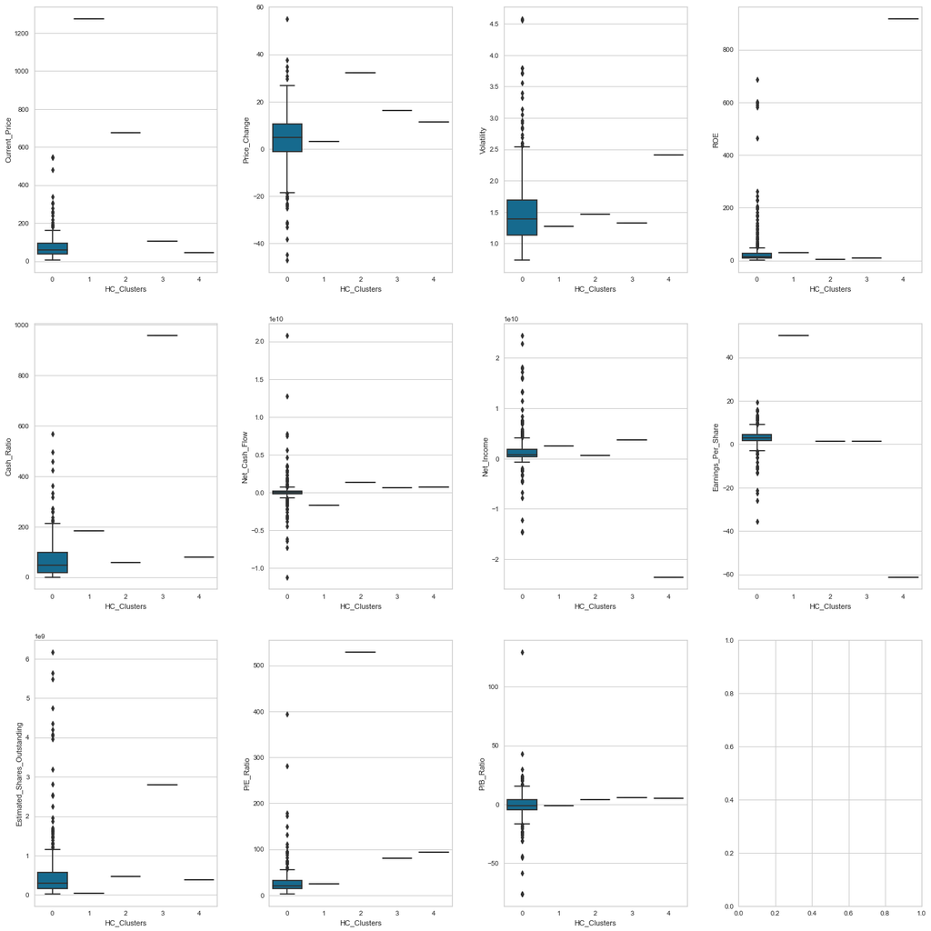

```python
fig, axes = plt.subplots(3, 4, figsize=(20, 20))
counter = 0

for ii in range(3):
    for jj in range(4):
        if counter < 11:
            sns.boxplot(
                ax=axes[ii][jj], data=df2, y=df2.columns[4 + counter], x="HC_Clusters",
            )
            counter = counter + 1

fig.tight_layout(pad=3.0)
```

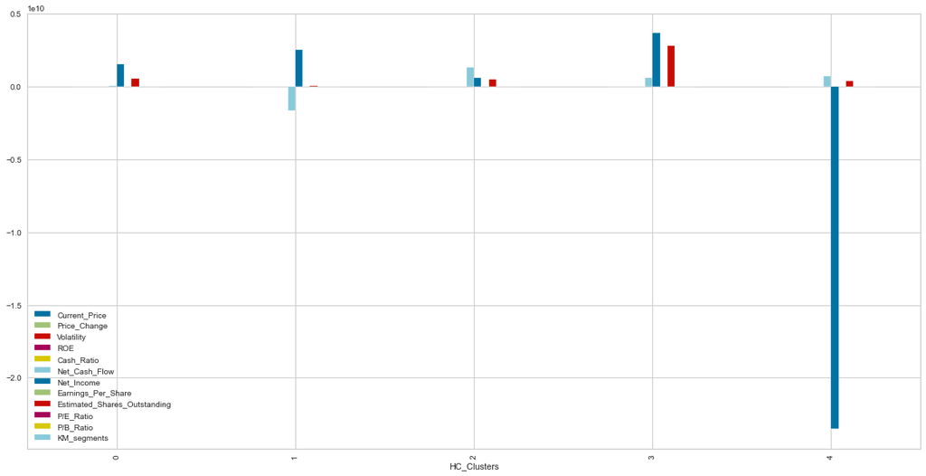

```python
df2.groupby("HC_Clusters").mean().plot.bar(figsize=(20, 10))
```

## K-means vs Hierarchical Clustering

You compare several things, like:

- Which clustering technique took less time for execution?
- Which clustering technique gave you more distinct clusters, or are they the same?
- How many observations are there in the similar clusters of both algorithms?
- How many clusters are obtained as the appropriate number of clusters from both algorithms?

You can also mention any differences or similarities you obtained in the cluster profiles from both the clustering techniques.

Hierarchical Clustering took less time to execute.

K-means clustering gave more distinct clusters.

K-means clustering has 7 clusters while Hierarchical Clustering has 5 clusters as appropriate number of clusters.

The sectors and company names are more spread among the k-means clusters, as 4 of the 5 sectors in hierarchial clusters have only 1 company each.